# COVID-19 Programming Challenge

Andrew Kalweit

2023-09-12

## Download and Setup Data

library(dplyr)

First, we read the Dataset sheet into “R”, name it “data”, and looked at a summary of columns to get a better sense of available variables. I changed location and continent to factors in case we used during analysis, and for later visualization purposes.

```r
rm(list = ls())
library(dplyr)
data <- read.csv("https://covid.ourworldindata.org/data/owid-covid-data.csv", na.strings = "", header=T)

#Look up the parameters available in the data
summary(data)
```

```
##    iso_code          continent           location             date
##  Length:339615      Length:339615      Length:339615      Length:339615
##  Class :character   Class :character   Class :character   Class :character
##  Mode  :character   Mode  :character   Mode  :character   Mode  :character
##
##
##
##
##   total_cases          new_cases       new_cases_smoothed  total_deaths
##  Min.   :        1   Min.   :      0   Min.   :      0    Min.   :      1
##  1st Qu.:     7736   1st Qu.:      0   1st Qu.:      0    1st Qu.:    125
##  Median :    67954   Median :      3   Median :     27    Median :   1287
##  Mean   :  6455498   Mean   :   9887   Mean   :   9925    Mean   :  84724
##  3rd Qu.:   710656   3rd Qu.:    288   3rd Qu.:    529    3rd Qu.:  11563
##  Max.   :770436563   Max.   :8401961   Max.   :6402036    Max.   :6956887
##  NA's   :37775       NA's   :9438      NA's   :10697      NA's   :59110
##    new_deaths      new_deaths_smoothed total_cases_per_million
##  Min.   :    0.0   Min.   :    0.000   Min.   :     0
##  1st Qu.:    0.0   1st Qu.:    0.000   1st Qu.:  2446
##  Median :    0.0   Median :    0.143   Median : 26269
##  Mean   :   88.1   Mean   :   88.428   Mean   : 98331
##  3rd Qu.:    3.0   3rd Qu.:    5.571   3rd Qu.:126418
##  Max.   :27939.0   Max.   :14822.000   Max.   :737554
##  NA's   :9395      NA's   :10625       NA's   :37775
##  new_cases_per_million new_cases_smoothed_per_million total_deaths_per_million
##  Min.   :     0.00     Min.   :    0.00               Min.   :   0.00
##  1st Qu.:     0.00     1st Qu.:    0.07               1st Qu.:  58.45
##  Median :     0.23     Median :    7.35               Median : 368.96
##  Mean   :   149.40     Mean   :  149.97               Mean   : 857.14
##  3rd Qu.:    38.62     3rd Qu.:   87.48               3rd Qu.:1326.91
##  Max.   :228872.02     Max.   :37241.78               Max.   :6501.22
##  NA's   :9438          NA's   :10697                  NA's   :59110
##  new_deaths_per_million new_deaths_smoothed_per_million reproduction_rate
##  Min.   :  0.000        Min.   :  0.000                 Min.   :-0.07
##  1st Qu.:  0.000        1st Qu.:  0.000                 1st Qu.: 0.72
##  Median :  0.000        Median :  0.015                 Median : 0.95
##  Mean   :  0.935        Mean   :  0.938                 Mean   : 0.91
##  3rd Qu.:  0.195        3rd Qu.:  0.626                 3rd Qu.: 1.14
##  Max.   :603.656        Max.   :148.641                 Max.   : 5.87
##  NA's   :9395           NA's   :10625                   NA's   :154798
```

[output cut: 137 more lines]

```
##  Min.   :-44.2               Min.   :-95.9
##  1st Qu.:  1.2               1st Qu.: -1.6
##  Median :  8.0               Median :  5.9
##  Mean   :  9.8               Mean   : 11.6
##  3rd Qu.: 15.5               3rd Qu.: 16.8
##  Max.   : 76.6               Max.   :386.9
##  NA's   :327863              NA's   :327863
##  excess_mortality_cumulative_per_million
##  Min.   :-2142
##  1st Qu.:   57
##  Median : 1048
##  Mean   : 1627
##  3rd Qu.: 2682
##  Max.   :10293
##  NA's   :327863
```

```r
unique(data$date)
```

```
##    [1] "2020-01-03" "2020-01-04" "2020-01-05" "2020-01-06" "2020-01-07"
##    [6] "2020-01-08" "2020-01-09" "2020-01-10" "2020-01-11" "2020-01-12"
##   [11] "2020-01-13" "2020-01-14" "2020-01-15" "2020-01-16" "2020-01-17"
##   [16] "2020-01-18" "2020-01-19" "2020-01-20" "2020-01-21" "2020-01-22"
##   [21] "2020-01-23" "2020-01-24" "2020-01-25" "2020-01-26" "2020-01-27"
##   [26] "2020-01-28" "2020-01-29" "2020-01-30" "2020-01-31" "2020-02-01"
##   [31] "2020-02-02" "2020-02-03" "2020-02-04" "2020-02-05" "2020-02-06"
##   [36] "2020-02-07" "2020-02-08" "2020-02-09" "2020-02-10" "2020-02-11"
##   [41] "2020-02-12" "2020-02-13" "2020-02-14" "2020-02-15" "2020-02-16"
##   [46] "2020-02-17" "2020-02-18" "2020-02-19" "2020-02-20" "2020-02-21"
##   [51] "2020-02-22" "2020-02-23" "2020-02-24" "2020-02-25" "2020-02-26"
##   [56] "2020-02-27" "2020-02-28" "2020-02-29" "2020-03-01" "2020-03-02"
##   [61] "2020-03-03" "2020-03-04" "2020-03-05" "2020-03-06" "2020-03-07"
##   [66] "2020-03-08" "2020-03-09" "2020-03-10" "2020-03-11" "2020-03-12"
##   [71] "2020-03-13" "2020-03-14" "2020-03-15" "2020-03-16" "2020-03-17"
```

[output cut: 255 more lines]

```r
#change continent, location to factors and assess the available countries and continent labels.
data$location <- factor(data$location)
data$continent <- factor(data$continent)
levels(data$location)
```

```
##   [1] "Afghanistan"                      "Africa"
##   [3] "Albania"                          "Algeria"
##   [5] "American Samoa"                   "Andorra"
##   [7] "Angola"                           "Anguilla"
##   [9] "Antigua and Barbuda"              "Argentina"
##  [11] "Armenia"                          "Aruba"
##  [13] "Asia"                             "Australia"
##  [15] "Austria"                          "Azerbaijan"
##  [17] "Bahamas"                          "Bahrain"
##  [19] "Bangladesh"                       "Barbados"
##  [21] "Belarus"                          "Belgium"
##  [23] "Belize"                           "Benin"
##  [25] "Bermuda"                          "Bhutan"
##  [27] "Bolivia"                          "Bonaire Sint Eustatius and Saba"
##  [29] "Bosnia and Herzegovina"           "Botswana"
```

[output cut: 113 more lines]

```r
levels(data$continent)
```

```
## [1] "Africa"        "Asia"          "Europe"        "North America"
## [5] "Oceania"       "South America"
```

## Developing an interesting and significant Model

I was interested in exploring a relationship between stringency of distancing measures (lockdown, etc) and smoking status in women. Can we show an interesting and significant relationship between smoking status and lockdowns? Like a good p-hacker, my goal was to find something interesting and work backwards to justify.

To do so, I limited the data set first to look for a significant relationship between the proportion of a country’s female population that is a smoker and the stringency of that government’s when implementing social distancing measures. I did the same looking for female smoking and excess mortality. On both, I looked for unique days where there might be an interesting explanation to catch a readers attention (instead of specifying an apriori hypothesis).

```r
res <- NULL
for (i in 1:length(unique(data$date))){
  data1 <- data[which((data$date==unique(data$date)[i])),]
  data1 <- data1 %>% select("iso_code","date","female_smokers", "stringency_index", "excess_mortality")
  if (sum(rowSums(!is.na(data1[,3:5]))==3)>=10){
    res <- rbind(res, c(unique(data$date)[i],
                        cor.test(data1[,3],data1[,4])$estimate,
                        cor.test(data1[,3],data1[,4])$p.value))
  }}

res[which((as.numeric(res[,2])>0)& (as.numeric(res[,3])<=0.05)),]
```

```
##                    cor
##  [1,] "2020-03-15" "0.269021923075868" "0.00141988445106934"
##  [2,] "2020-11-08" "0.177889142451503" "0.0368524350800879"
##  [3,] "2020-11-15" "0.209919675495865" "0.0134673204548778"
##  [4,] "2020-11-22" "0.211537826410419" "0.0127507405794217"
##  [5,] "2020-11-29" "0.225852551628827" "0.00773230516774806"
##  [6,] "2020-11-30" "0.218177428909334" "0.0101481765576349"
##  [7,] "2020-12-06" "0.209111873245201" "0.0138380374622237"
##  [8,] "2020-12-13" "0.208684841442575" "0.0140375878935917"
##  [9,] "2020-12-20" "0.226355078379705" "0.00759358457580504"
## [10,] "2020-12-27" "0.244624355300334" "0.00383269709993301"
## [11,] "2020-12-31" "0.25295731044469"  "0.00275900140261703"
## [12,] "2021-01-03" "0.257544653273224" "0.00229176800015385"
## [13,] "2021-01-10" "0.215193930550374" "0.0112533504218389"
## [14,] "2021-01-17" "0.21282114769609"  "0.0122063873132674"
## [15,] "2021-01-24" "0.207844568610569" "0.0144375886509605"
## [16,] "2021-01-31" "0.21228443031573"  "0.0124315216066068"
## [17,] "2021-02-07" "0.204124833773825" "0.0163300535852288"
## [18,] "2021-02-14" "0.177877497132416" "0.0368649796736626"
## [19,] "2021-02-21" "0.187656782151193" "0.0275218679624587"
## [20,] "2021-02-28" "0.222991251888518" "0.0085657827126477"
## [21,] "2021-03-07" "0.219805102572279" "0.00958648084440256"
## [22,] "2021-03-14" "0.211100665625888" "0.0129409646829203"
## [23,] "2021-03-21" "0.198788610621974" "0.0194197545321641"
## [24,] "2021-03-28" "0.188083136049709" "0.0271653240852236"
## [25,] "2021-03-31" "0.20612705777429"  "0.0152862150624701"
## [26,] "2021-04-04" "0.206199402787407" "0.0152496118934848"
## [27,] "2021-04-11" "0.201371905835465" "0.017866078382274"
```

```r
res <- NULL
for (i in 1:length(unique(data$date))){
  data1 <- data[which((data$date==unique(data$date)[i])),]
  data1 <- data1 %>% select("iso_code","date","female_smokers", "stringency_index", "excess_mortality")
  if (sum(rowSums(!is.na(data1[,3:5]))==3)>=10){
    res <- rbind(res, c(unique(data$date)[i],
                        cor.test(data1[,3],data1[,5])$estimate,
                        cor.test(data1[,3],data1[,5])$p.value))
  }}

res[which((as.numeric(res[,2])>0)& (as.numeric(res[,3])<=0.05)),]
```

```
##                    cor
##  [1,] "2020-04-30" "0.374637062449639" "0.00947375791408691"
##  [2,] "2020-12-31" "0.315776632479448" "0.0325334280168954"
##  [3,] "2021-11-07" "0.415570644530444" "0.00452660258161863"
##  [4,] "2021-11-14" "0.432215899863249" "0.0030271781347354"
##  [5,] "2021-11-21" "0.527992999148754" "0.000193345586643165"
##  [6,] "2021-11-28" "0.555488079934288" "7.46657303619244e-05"
##  [7,] "2021-12-05" "0.601708562499856" "1.23171524395681e-05"
##  [8,] "2021-12-12" "0.509414922173733" "0.000351638970009431"
##  [9,] "2021-12-19" "0.420961198261448" "0.0039822786748301"
## [10,] "2021-12-31" "0.343963214536175" "0.0276650945751407"
## [11,] "2022-10-02" "0.464613676500273" "0.0013031054556071"
```

## Narrowing down to New Year’s Eve 2020

I noticed that there was a significant correlation between a countries proportion of female smokers and the stringency of a governments response on the first New Year’s Even during the pandemic (a holiday broadly celebrated in many countries). Also female smoking was related to excess mortality in a country (which makes some sense given smoking might be related to hightened severity or complications of COVID-19).

```r
dataNYE <- data[which((data$date=="2020-12-31")),]
summary(dataNYE)
```

```
##    iso_code                 continent            location       date
##  Length:252         Africa       :57   Afghanistan   :  1   Length:252
##  Class :character   Asia         :49   Africa        :  1   Class :character
##  Mode  :character   Europe       :55   Albania       :  1   Mode  :character
##                     North America:41   Algeria       :  1
##                     Oceania      :24   American Samoa:  1
##                     South America:14   Andorra       :  1
##                     NA's         :12   (Other)       :246
##   total_cases         new_cases        new_cases_smoothed  total_deaths
##  Min.   :       1   Min.   :     0.0   Min.   :     0.0   Min.   :      1.0
##  1st Qu.:    2514   1st Qu.:     0.0   1st Qu.:     5.3   1st Qu.:     79.8
##  Median :   22347   Median :    45.5   Median :    93.9   Median :    601.0
##  Mean   : 1490382   Mean   : 10966.3   Mean   :  9796.6   Mean   :  39103.1
##  3rd Qu.:  203268   3rd Qu.:  1015.5   3rd Qu.:  1217.3   3rd Qu.:   4791.8
##  Max.   :82334787   Max.   :652691.0   Max.   :574448.7   Max.   :1936738.0
##  NA's   :21         NA's   :6          NA's   :6          NA's   :44
##    new_deaths       new_deaths_smoothed total_cases_per_million
##  Min.   :    0.00   Min.   :    0.000   Min.   :    0.26
##  1st Qu.:    0.00   1st Qu.:    0.000   1st Qu.: 1032.27
##  Median :    0.00   Median :    1.071   Median : 7791.26
##  Mean   :  202.46   Mean   :  204.682   Mean   :16144.10
##  3rd Qu.:   14.75   3rd Qu.:   23.500   3rd Qu.:28400.83
##  Max.   :11956.00   Max.   :11755.571   Max.   :99983.72
##  NA's   :6          NA's   :6           NA's   :21
##  new_cases_per_million new_cases_smoothed_per_million total_deaths_per_million
##  Min.   :   0.000      Min.   :   0.000               Min.   :   0.155
##  1st Qu.:   0.000      1st Qu.:   2.166               1st Qu.:  23.613
##  Median :   9.476      Median :  22.783               Median : 145.006
##  Mean   : 124.635      Mean   : 116.255               Mean   : 326.880
##  3rd Qu.: 135.974      3rd Qu.: 165.167               3rd Qu.: 453.201
##  Max.   :2662.423      Max.   :2024.141               Max.   :2733.249
##  NA's   :6             NA's   :6                      NA's   :44
##  new_deaths_per_million new_deaths_smoothed_per_million reproduction_rate
##  Min.   : 0.000         Min.   : 0.000                  Min.   :0.0000
##  1st Qu.: 0.000         1st Qu.: 0.000                  1st Qu.:0.8600
##  Median : 0.000         Median : 0.181                  Median :1.0300
##  Mean   : 1.834         Mean   : 2.154                  Mean   :0.9924
##  3rd Qu.: 1.437         3rd Qu.: 2.924                  3rd Qu.:1.1725
##  Max.   :30.248         Max.   :43.560                  Max.   :2.0900
##  NA's   :6              NA's   :6                       NA's   :72
```

[output cut: 137 more lines]

```
##  Min.   :-20.38              Min.   :-45.16
##  1st Qu.:  0.16              1st Qu.:  3.04
##  Median :  9.28              Median : 14.51
##  Mean   : 10.52              Mean   : 26.30
##  3rd Qu.: 18.59              3rd Qu.: 41.21
##  Max.   : 43.64              Max.   :192.40
##  NA's   :183                 NA's   :183
##  excess_mortality_cumulative_per_million
##  Min.   :-1620.162
##  1st Qu.:    8.611
##  Median :  323.696
##  Mean   :  628.334
##  3rd Qu.: 1152.812
##  Max.   : 3572.842
##  NA's   :183
```

```r
unique(dataNYE$date)
```

```
## [1] "2020-12-31"
```

```r
model <- lm(female_smokers ~ stringency_index, dataNYE)
summary(model)
```

```
##
## Call:
## lm(formula = female_smokers ~ stringency_index, data = dataNYE)
##
## Residuals:
##     Min      1Q  Median      3Q     Max
## -14.092  -7.681  -3.621   6.749  31.023
##
## Coefficients:
##                  Estimate Std. Error t value Pr(>|t|)
## (Intercept)        1.4687     3.1074   0.473  0.63722
## stringency_index   0.1534     0.0503   3.049  0.00276 **
## ---
## Signif. codes:  0 '***' 0.001 '**' 0.01 '*' 0.05 '.' 0.1 ' ' 1
##
## Residual standard error: 10.01 on 136 degrees of freedom
##   (114 observations deleted due to missingness)
## Multiple R-squared:  0.06399,    Adjusted R-squared:  0.0571
## F-statistic: 9.297 on 1 and 136 DF,  p-value: 0.002759
```

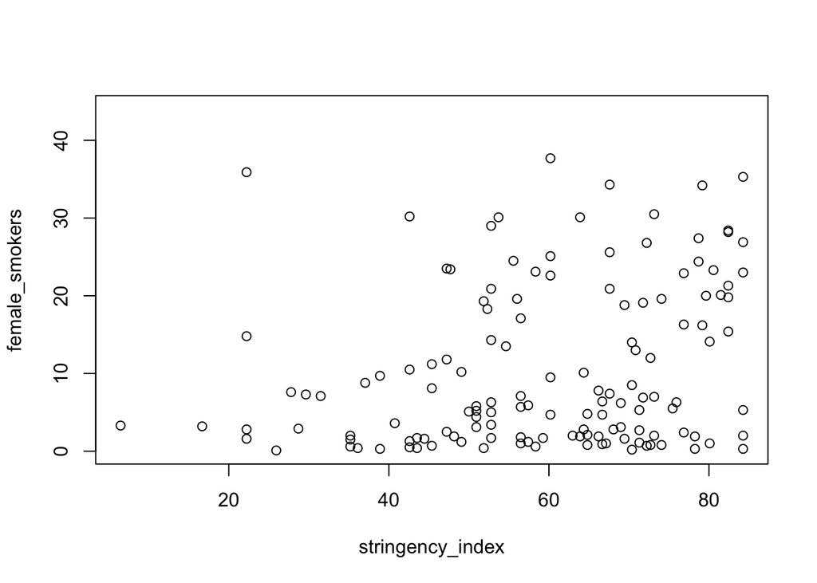

```r
plot(female_smokers ~ stringency_index, dataNYE)
```

# Cherry-picking what to display.

Lastly, seeing that smoking is related to stringency, I wanted to show that excess mortality is predicted by female smoking rate, even when controlling for the stringency of a government’s response. This helps me argue that the excess mortality of the pandemic is more due to smoking, and NOT mediated by social distancing. I tested this to see if it worked at giving me a p-value <..05 before deciding whether to report it.

Two notes: (1) excess mortality isn’t a great variable to select if I were really serious because its missing in the vast majority of countries compared to my other analyses and limits my power (but this works in my favor for finding significance here) and (2) I cherry picked ONLY these 3 variables to get an interesting arguement to report without doing the work of actually systemically picking and testing a hypothesis (as per the assignment).

```r
cor.test(dataNYE$female_smokers, dataNYE$excess_mortality)
```

```
##
##  Pearson's product-moment correlation
##
## data:  dataNYE$female_smokers and dataNYE$excess_mortality
## t = 2.2076, df = 44, p-value = 0.03253
## alternative hypothesis: true correlation is not equal to 0
## 95 percent confidence interval:
##  0.0280499 0.5551816
## sample estimates:
##       cor
## 0.3157766
```

```r
m<-lm(excess_mortality ~ female_smokers + stringency_index, dataNYE)
summary(m)
```

```
##
## Call:
## lm(formula = excess_mortality ~ female_smokers + stringency_index,
##     data = dataNYE)
##
## Residuals:
##     Min      1Q  Median      3Q     Max
## -52.817 -18.873  -7.467   9.487 164.473
##
## Coefficients:
##                  Estimate Std. Error t value Pr(>|t|)
## (Intercept)      -16.8417    21.6310  -0.779   0.4407
## female_smokers     1.4425     0.5791   2.491   0.0169 *
## stringency_index   0.5262     0.3377   1.558   0.1269
## ---
## Signif. codes:  0 '***' 0.001 '**' 0.01 '*' 0.05 '.' 0.1 ' ' 1
##
## Residual standard error: 34.1 on 41 degrees of freedom
##   (208 observations deleted due to missingness)
## Multiple R-squared:  0.1722, Adjusted R-squared:  0.1318
## F-statistic: 4.264 on 2 and 41 DF,  p-value: 0.02078
```

## P-HACKED Conclusions & Rationale:

Finally, I (1) graphed the linear model of my main relationship (with a misleading/strongly worded title to really sell it), (2) ran a cherry-picked linear model to show “no significant” predictors for the stringency index, and (3) and wrote a (logically unsound) arguement stitching it all together based on this cherry-picked set of analysis:

[figure not shown]

```r
model2 <- lm(stringency_index ~ new_cases_smoothed_per_million + icu_patients_per_million + hosp_patients_per_million +
               positive_rate, dataNYE)
summary(model2)
```

```
##
## Call:
## lm(formula = stringency_index ~ new_cases_smoothed_per_million +
##     icu_patients_per_million + hosp_patients_per_million + positive_rate,
##     data = dataNYE)
##
## Residuals:
##     Min      1Q  Median      3Q     Max
## -18.689  -7.314  -0.636   8.335  15.327
##
## Coefficients:
##                                  Estimate Std. Error t value Pr(>|t|)
## (Intercept)                     63.255465   4.708734  13.434 1.76e-10 ***
## new_cases_smoothed_per_million   0.012530   0.014348   0.873    0.395
## icu_patients_per_million         0.155737   0.137941   1.129    0.275
## hosp_patients_per_million       -0.002111   0.011392  -0.185    0.855
## positive_rate                  -41.379379  36.255815  -1.141    0.270
## ---
## Signif. codes:  0 '***' 0.001 '**' 0.01 '*' 0.05 '.' 0.1 ' ' 1
##
## Residual standard error: 10.55 on 17 degrees of freedom
##   (230 observations deleted due to missingness)
## Multiple R-squared:  0.1934, Adjusted R-squared:  0.00361
## F-statistic: 1.019 on 4 and 17 DF,  p-value: 0.4254
```

## Final Arguement

Across the world, women were more likely to smoke on the first New Year’s Eve during the COVID-19 pandemic if their government had a more stringent response to the pandemic.

During 2020, stringent governments implemented more a more complete array of school closures, workplace closures, cancellation of public events, restrictions on public gatherings, closures of public transport, stay-at-home requirements, public information campaigns, restrictions on internal movements, and international travel controls. Because of this, we hypothesized that women living in “stricter” governments were more likely to smoke in response to the social stressors related COVID-19 pandemic due staying at home, tending to household responsibilities, and missing out on “relaxing” social events such as New Year’s Eve (a commonly celebrated social holiday across many countries).

In fact, our data-based linear model significantly predicted that female smoking rates in a country were related to Oxford Coronavirus Government Response Tracker’s (OxCGRT) Stringency index scale on New Years Eve 2020 (p-value = 0.00276). For every 1 point increase in the stringency index, an additional 0.1534% of a country’s female population were smokers. This means that countries that were 50 pts more strict on this index were predicted to have an additional 7.67% of their women smoking on New Year’s Eve in 2020.

Furthermore, excess mortality in a country (per million population) was significantly predicted in a linear model by female smoking rates (p = 0.0169) when controlling for the stringency of the countries government response (which was NOT significant with p > 0.05). This suggests that country’s unusual rates of mortality during the COVID-19 pandemic were more likely due to chronic behavioral risk factors and morbidity caused by complication of increased smoking than it was impacted by government responses taken to prevent the spread of COVID-19. Lastly, a country’s stringency index on New Year’s Eve 2020 was not significantly predicted in a linear model by the country’s number of ICU patients, new cases, or hospitalization rate (per million) (all p>.27). This suggests that a country’s strictness was not actually related to the strength of their COVID-19 response measures.

Excess mortality was predicted by female smoking rates, and these rates were predicted by a government’s stringency on New Years Eve 2020. This analysis suggests that, across the world, it may have been better for a country’s pandemic-era mortality to focus on discouraging harmful health behvaiors such as smoking instead of prevention via social distancing, and that lockdown measures may have had counter-productive effects.